# Pseudobulk differential expression with DESeq2

Local version, reads from the workshop data repo, no network access

Published

August 4, 2026

**ImportantRead this before you trust anything below**

This document is a transcription of the upstream HBC lesson *Single-cell RNA-seq: Pseudobulk differential expression analysis* (https://hbctraining.github.io/scRNA-seq/lessons/pseudobulk_DESeq2_scrnaseq.html), adapted only so that it reads its input from the workshop data repo instead of a downloaded `data/` folder.

The document renders end to end. Two chunks fail on purpose and are recovered by a fallback in the very next chunk, so the rendered page shows exactly two error blocks and then keeps going.

The upstream page carries an **ARCHIVED** banner and the lesson script is dated **May 2020**. Expect API drift against current DESeq2, Seurat, and scater. Two calls are known to be affected. `scater::calculateQCMetrics()` is now defunct, and `Matrix.utils` was archived on CRAN so `aggregate.Matrix()` is unavailable. Both are transcribed as the tutorial has them, each followed by a modern equivalent. The document sets `error: false`, so any unexpected failure stops the render and is reported. These two chunks, `qc-tutorial` and `aggregate-tutorial`, carry a chunk-level `error: true` because their failure is the point being taught.

## Learning objectives

- Understand how to prepare single-cell RNA-seq raw count data for pseudobulk differential expression analysis.
- Use DESeq2 to perform pseudobulk differential expression analysis on a specific cell type cluster.
- Create functions to iterate the pseudobulk differential expression analysis across different cell types.

## Differential expression analysis with DESeq2

After identifying the cell type identities of the scRNA-seq clusters, we often want to perform differential expression analysis between conditions within particular cell types. Functions exist within Seurat to do this, but the p-values are often inflated because each cell is treated as a sample. Single cells within a sample are not independent of each other. If we treat cells as samples we are investigating variation within an individual, not variation across a population.

The current best practice is a pseudobulk approach:

1. Subset to the cells for the cell type(s) of interest.
2. Extract the raw counts after QC filtering.
3. Aggregate the counts and metadata to the sample level.
4. Perform the DE analysis. At least two biological replicates per condition are required, and more are recommended.

## Setting up the R environment

```r
source(here::here("slides", "find_data_dir.R"))
data_dir <- find_data_dir("2_a_pseudobulk_de")
report_data_dir("2_a_pseudobulk_de")
```

### Where the data came from

Upstream tells students to right-click and download the RDS object into a `data/` folder. The verbatim download link on the lesson page is:

```
https://www.dropbox.com/s/dgdooocb1a03dvk/scRNA-seq_input_data_for_DE.rds?dl=1
```

For the workshop that file is already staged, so the chunks below read it from `data_dir` and never touch the network.

### Load libraries

```r
# May 2020
# Single-cell RNA-seq analysis - Pseudobulk DE analysis with DESeq2

# Load libraries
library(scater)
library(Seurat)
library(tidyverse)
library(cowplot)
# library(Matrix.utils)  # archived on CRAN; not loaded. See the aggregation
#                        # section, which shows aggregate.Matrix() failing and
#                        # uses a Matrix-only replacement instead.
library(edgeR)
library(dplyr)
library(magrittr)
library(Matrix)
library(purrr)
library(reshape2)
library(S4Vectors)
library(tibble)
library(SingleCellExperiment)
library(pheatmap)
library(apeglm)
library(png)
library(DESeq2)
library(RColorBrewer)
```

The table below records which packages the tutorial uses and their versions, including the archived `Matrix.utils`, which is intentionally not loaded above. It is a quick way to confirm the environment before running the analysis.

```r
needed <- c("scater", "Seurat", "tidyverse", "cowplot", "Matrix.utils",
            "edgeR", "dplyr", "magrittr", "Matrix", "purrr", "reshape2",
            "S4Vectors", "tibble", "SingleCellExperiment", "pheatmap",
            "apeglm", "png", "DESeq2", "RColorBrewer", "DEGreport", "scuttle")
data.frame(
  package = needed,
  installed = vapply(needed, requireNamespace, logical(1), quietly = TRUE),
  version = vapply(needed,
                   function(p) {
                     if (requireNamespace(p, quietly = TRUE)) {
                       as.character(utils::packageVersion(p))
                     } else {
                       NA_character_
                     }
                   },
                   character(1)),
  row.names = NULL)
```

```
                package installed version
1                scater      TRUE  1.40.2
2                Seurat      TRUE   5.5.1
3             tidyverse      TRUE   2.0.0
4               cowplot      TRUE   1.2.0
5          Matrix.utils     FALSE    <NA>
6                 edgeR      TRUE  4.10.1
7                 dplyr      TRUE   1.2.1
8              magrittr      TRUE   2.0.5
9                Matrix      TRUE   1.7.5
10                purrr      TRUE   1.2.2
11             reshape2      TRUE   1.4.5
12            S4Vectors      TRUE  0.50.1
13               tibble      TRUE   3.3.1
14 SingleCellExperiment      TRUE  1.34.0
15             pheatmap      TRUE  1.0.13
16               apeglm      TRUE  1.34.0
17                  png      TRUE   0.1.9
18               DESeq2      TRUE  1.52.0
19         RColorBrewer      TRUE   1.1.3
20            DEGreport      TRUE  1.48.0
21              scuttle      TRUE  1.22.0
```

### Load the RDS object

```r
# Read in the dataset
sce <- readRDS(file.path(data_dir, "scRNA-seq_input_data_for_DE.rds"))
sce
```

```
class: SingleCellExperiment
dim: 35635 29065
metadata(0):
assays(1): counts
rownames(35635): MIR1302-10 FAM138A ... MT-ND6 MT-CYB
rowData names(2): ENSEMBL SYMBOL
colnames(29065): AAACATACAATGCC-1 AAACATACATTTCC-1 ... TTTGCATGGTTTGG-1
  TTTGCATGTCTTAC-1
colData names(5): ind stim cluster cell multiplets
reducedDimNames(1): TSNE
mainExpName: NULL
altExpNames(0):
```

### Deriving the aggregation metadata

**ImportantThe staged object is the raw Kang object, so we build the three key columns here**

The upstream lesson assumes `sce` already carries `cluster_id`, `sample_id`, and `group_id`. The object distributed for this workshop is the raw Kang et al. 2017 `SingleCellExperiment`, whose `colData` instead has `cell` (cell type), `ind` (individual), and `stim` (condition). We derive the three columns the tutorial needs, exactly as `muscat::prepSCE()` would: `cluster_id` from the cell type, `group_id` from the condition, and `sample_id` from condition plus individual (so `ctrl` and individual `101` give sample `ctrl101`). Without this step every chunk below fails, because `sce$cluster_id` and friends are `NULL`.

```r
# Drop the handful of cells with no cell-type assignment.
sce <- sce[, !is.na(sce$cell)]

sce$cluster_id <- factor(sce$cell)
sce$group_id   <- factor(sce$stim)
sce$sample_id  <- factor(paste0(sce$stim, sce$ind))

head(colData(sce)[, c("cluster_id", "sample_id", "group_id")])
```

```
DataFrame with 6 rows and 3 columns
                      cluster_id sample_id group_id
                        <factor>  <factor> <factor>
AAACATACAATGCC-1 CD4 T cells      ctrl107      ctrl
AAACATACATTTCC-1 CD14+ Monocytes  ctrl1016     ctrl
AAACATACCAGAAA-1 CD14+ Monocytes  ctrl1256     ctrl
AAACATACCAGCTA-1 CD14+ Monocytes  ctrl1256     ctrl
AAACATACCATGCA-1 CD4 T cells      ctrl1488     ctrl
AAACATACCTCGCT-1 CD14+ Monocytes  ctrl1256     ctrl
```

## Exploring the dataset

The data is the Kang et al. 2017 lupus PBMC dataset, the same one used for the rest of the single-cell workflow. Here it is the non-pooled count data with eight control samples and eight interferon stimulated samples, so there are real biological replicates to work with.

```r
# Explore the raw counts for the dataset

## Check the assays present
assays(sce)
```

```
List of length 1
names(1): counts
```

```r
## Explore the raw counts for the dataset
dim(counts(sce))
```

```
[1] 35635 29056
```

```r
counts(sce)[1:6, 1:6]
```

```
6 x 6 sparse Matrix of class "dgCMatrix"
             AAACATACAATGCC-1 AAACATACATTTCC-1 AAACATACCAGAAA-1
MIR1302-10                  .                .                .
FAM138A                     .                .                .
OR4F5                       .                .                .
RP11-34P13.7                .                .                .
RP11-34P13.8                .                .                .
AL627309.1                  .                .                .
             AAACATACCAGCTA-1 AAACATACCATGCA-1 AAACATACCTCGCT-1
MIR1302-10                  .                .                .
FAM138A                     .                .                .
OR4F5                       .                .                .
RP11-34P13.7                .                .                .
RP11-34P13.8                .                .                .
AL627309.1                  .                .                .
```

We do not run `head()` on this object, since it would print thousands of columns. We look at the first six rows and columns instead.

```r
## Explore the cellular metadata for the dataset
dim(colData(sce))
```

```
[1] 29056     8
```

```r
head(colData(sce))
```

```
DataFrame with 6 rows and 8 columns
                       ind     stim   cluster            cell multiplets
                 <integer> <factor> <integer>        <factor>   <factor>
AAACATACAATGCC-1       107     ctrl         5 CD4 T cells        doublet
AAACATACATTTCC-1      1016     ctrl         9 CD14+ Monocytes    singlet
AAACATACCAGAAA-1      1256     ctrl         9 CD14+ Monocytes    singlet
AAACATACCAGCTA-1      1256     ctrl         9 CD14+ Monocytes    doublet
AAACATACCATGCA-1      1488     ctrl         3 CD4 T cells        singlet
AAACATACCTCGCT-1      1256     ctrl         9 CD14+ Monocytes    singlet
                      cluster_id group_id sample_id
                        <factor> <factor>  <factor>
AAACATACAATGCC-1 CD4 T cells         ctrl  ctrl107
AAACATACATTTCC-1 CD14+ Monocytes     ctrl  ctrl1016
AAACATACCAGAAA-1 CD14+ Monocytes     ctrl  ctrl1256
AAACATACCAGCTA-1 CD14+ Monocytes     ctrl  ctrl1256
AAACATACCATGCA-1 CD4 T cells         ctrl  ctrl1488
AAACATACCTCGCT-1 CD14+ Monocytes     ctrl  ctrl1256
```

For every cell we have the condition (`ctrl` or `stim`), the sample ID, and the cell type.

## Acquiring necessary metrics for aggregation across cells in a sample

```r
# Named vector of cluster names
kids <- purrr::set_names(levels(sce$cluster_id))
kids
```

```
            B cells     CD14+ Monocytes         CD4 T cells         CD8 T cells
          "B cells"   "CD14+ Monocytes"       "CD4 T cells"       "CD8 T cells"
    Dendritic cells   FCGR3A+ Monocytes      Megakaryocytes            NK cells
  "Dendritic cells" "FCGR3A+ Monocytes"    "Megakaryocytes"          "NK cells"
```

```r
# Total number of clusters
nk <- length(kids)
nk
```

```
[1] 8
```

```r
# Named vector of sample names
sids <- purrr::set_names(levels(sce$sample_id))

# Total number of samples
ns <- length(sids)
ns
```

```
[1] 16
```

To perform sample-level DE we need sample-level metadata. We reorder the single-cell metadata to match the order of the sample ID factor levels, then take the sample-level information from the first cell of each sample.

```r
# Generate sample level metadata

## Determine the number of cells per sample
table(sce$sample_id)
```

```
 ctrl101 ctrl1015 ctrl1016 ctrl1039  ctrl107 ctrl1244 ctrl1256 ctrl1488
    1027     3138     2180      551      645     2250     2451     2375
 stim101 stim1015 stim1016 stim1039  stim107 stim1244 stim1256 stim1488
    1363     2703     1998      791      641     1755     2274     2914
```

```r
## Turn named vector into a numeric vector of number of cells per sample
n_cells <- as.numeric(table(sce$sample_id))

## Determine how to reorder the samples (rows) of the metadata to match the
## order of sample names in the sids vector
m <- match(sids, sce$sample_id)

## Create the sample level metadata by combining the reordered metadata with
## the number of cells corresponding to each sample.
ei <- data.frame(colData(sce)[m, ],
                 n_cells, row.names = NULL) %>%
  dplyr::select(-"cluster_id")
ei
```

```
    ind stim cluster            cell multiplets group_id sample_id n_cells
1   101 ctrl       5     CD4 T cells    doublet     ctrl   ctrl101    1027
2  1015 ctrl       9 CD14+ Monocytes    singlet     ctrl  ctrl1015    3138
3  1016 ctrl       9 CD14+ Monocytes    singlet     ctrl  ctrl1016    2180
4  1039 ctrl       4 Dendritic cells    singlet     ctrl  ctrl1039     551
5   107 ctrl       5     CD4 T cells    doublet     ctrl   ctrl107     645
6  1244 ctrl       5     CD4 T cells    singlet     ctrl  ctrl1244    2250
7  1256 ctrl       9 CD14+ Monocytes    singlet     ctrl  ctrl1256    2451
8  1488 ctrl       3     CD4 T cells    singlet     ctrl  ctrl1488    2375
9   101 stim      10     CD8 T cells    singlet     stim   stim101    1363
10 1015 stim      10     CD8 T cells    singlet     stim  stim1015    2703
11 1016 stim       8 CD14+ Monocytes    singlet     stim  stim1016    1998
12 1039 stim       4  Megakaryocytes    doublet     stim  stim1039     791
13  107 stim       7        NK cells    singlet     stim   stim107     641
14 1244 stim       6     CD4 T cells       ambs     stim  stim1244    1755
15 1256 stim       6     CD4 T cells    singlet     stim  stim1256    2274
16 1488 stim       2 Dendritic cells    singlet     stim  stim1488    2914
```

## Quality control

Upstream removes count outliers and low count genes with `scater`, following the 2019 Bioconductor tutorial. A real analysis would do a more careful and more hands-on job of QC.

```r
# Perform QC if not already performed
dim(sce)
```

```
[1] 35635 29056
```

```r
# Calculate quality control (QC) metrics. This is the upstream call, and it fails
# on purpose: calculateQCMetrics() is defunct in current scater. The next chunk
# computes the same is_outlier flag with scuttle, the modern equivalent.
sce <- calculateQCMetrics(sce)
```

```
Error in `calculateQCMetrics()`:
! 'calculateQCMetrics' is defunct.
Use 'perCellQCMetrics' instead.
See help("Defunct")
```

**Warning`calculateQCMetrics()` was removed from scater**

`scater::calculateQCMetrics()` and the `total_features_by_counts` column it created were deprecated in Bioconductor 3.10 and removed after that. The modern equivalent lives in `scuttle`, where the per-cell count of detected genes is called `detected`. The chunk below computes `sce$is_outlier` the modern way, but only if the tutorial chunk above failed to create it, so the tutorial code stays authoritative when it happens to work.

```r
if (is.null(sce$is_outlier)) {
  message("calculateQCMetrics() did not run. Using scuttle::perCellQCMetrics().")
  qc <- scuttle::perCellQCMetrics(sce)
  sce$total_features_by_counts <- qc$detected
  sce$is_outlier <- scuttle::isOutlier(
    metric = qc$detected,
    nmads = 2, type = "both", log = TRUE)
}
table(sce$is_outlier)
```

```
FALSE  TRUE
26828  2228
```

```r
# Remove outlier cells
sce <- sce[, !sce$is_outlier]
dim(sce)
```

```
[1] 35635 26828
```

```r
## Remove lowly expressed genes which have less than 10 cells with any counts
sce <- sce[rowSums(counts(sce) > 1) >= 10, ]

dim(sce)
```

```
[1]  7120 26828
```

## Count aggregation to sample level

We take the sum of counts for each sample within each cell type.

```r
# Aggregate the counts per sample_id and cluster_id

# Subset metadata to only include the cluster and sample IDs to aggregate across
groups <- colData(sce)[, c("cluster_id", "sample_id")]

# Aggregate across cluster-sample groups. This is the upstream call, and it fails
# on purpose: aggregate.Matrix() lived in the archived Matrix.utils. The
# Matrix-only replacement two chunks down produces the same sums, and the chunk
# after it inspects the result.
pb <- aggregate.Matrix(t(counts(sce)),
                       groupings = groups, fun = "sum")
```

```
Error in `aggregate.Matrix()`:
! could not find function "aggregate.Matrix"
```

**Important`Matrix.utils` is archived on CRAN**

`Matrix.utils` was archived on CRAN in 2020, so `aggregate.Matrix()` may simply not be installable on a current R. The commented-out chunk below does the same sum-by-group using only `Matrix`, which is a base recommended package. A sparse model matrix of group indicators, crossproduct with the cell-by-gene matrix, gives exactly the group-by-gene sums that `aggregate.Matrix(fun = "sum")` returns, with the same `cluster_sample` row names.

The chunk after it runs that fallback for real, but only when `pb` does not already exist, so the document can carry on to DESeq2 either way.

```r
# # Matrix-only replacement for Matrix.utils::aggregate.Matrix(fun = "sum")
#
# group_key <- factor(paste(colData(sce)$cluster_id,
#                           colData(sce)$sample_id,
#                           sep = "_"))
#
# # One indicator column per cluster-sample group, cells in rows.
# mm <- Matrix::sparse.model.matrix(~ 0 + group_key)
# colnames(mm) <- levels(group_key)
#
# # crossprod(mm, cells_by_genes) sums each gene over the cells of each group.
# pb <- Matrix::crossprod(mm, Matrix::t(counts(sce)))
```

```r
if (!exists("pb")) {
  message("aggregate.Matrix() unavailable. Using the Matrix-only fallback.")
  group_key <- factor(paste(colData(sce)$cluster_id,
                            colData(sce)$sample_id,
                            sep = "_"))
  mm <- Matrix::sparse.model.matrix(~ 0 + group_key)
  colnames(mm) <- levels(group_key)
  pb <- Matrix::crossprod(mm, Matrix::t(counts(sce)))
}
class(pb)
```

```
[1] "dgCMatrix"
attr(,"package")
[1] "Matrix"
```

```r
dim(pb)
```

```
[1]  128 7120
```

```r
pb[1:6, 1:6]
```

```
6 x 6 sparse Matrix of class "dgCMatrix"
                 NOC2L HES4 ISG15 TNFRSF18 TNFRSF4 SDF4
B cells_ctrl101     12    .    13        8       1   13
B cells_ctrl1015    37    4   136       55      16   42
B cells_ctrl1016    13    3    42       10       .   15
B cells_ctrl1039     2    1    16        3       1    1
B cells_ctrl107      7    .     6        3       4    5
B cells_ctrl1244    24    7    25       30      11    7
```

The output is a sparse matrix with cell type-sample rows and gene columns. For example, within B cells, sample `ctrl101` has a count for gene `NOC2L`.

To run DE per cell type we need to split the data by cell type, and transpose each piece so that genes are rows and samples are columns. Not every sample contains cells of every cell type, so we first work out which rows belong to which cluster.

```r
# Not every cluster is present in all samples; create a vector that represents
# how to split samples
splitf <- sapply(stringr::str_split(rownames(pb),
                                    pattern = "_",
                                    n = 2),
                 `[`, 1)

# Turn into a list and split the list into components for each cluster and
# transform, so rows are genes and columns are samples and make rownames as the
# sample IDs
pb <- split.data.frame(pb,
                       factor(splitf)) %>%
  lapply(function(u)
    set_colnames(t(u),
                 stringr::str_extract(rownames(u), "(?<=_)[:alnum:]+")))

class(pb)
```

```
[1] "list"
```

```r
# Explore the different components of list
str(pb)
```

```
List of 8
 $ B cells          :Formal class 'dgCMatrix' [package "Matrix"] with 6 slots
  .. ..@ i       : int [1:94584] 0 2 3 4 5 6 7 8 10 11 ...
  .. ..@ p       : int [1:17] 0 5979 12725 18917 23282 28188 34400 40943 47478 53573 ...
  .. ..@ Dim     : int [1:2] 7120 16
  .. ..@ Dimnames:List of 2
  .. .. ..$ : chr [1:7120] "NOC2L" "HES4" "ISG15" "TNFRSF18" ...
  .. .. ..$ : chr [1:16] "ctrl101" "ctrl1015" "ctrl1016" "ctrl1039" ...
  .. ..@ x       : num [1:94584] 12 13 8 1 13 9 1 11 24 3 ...
  .. ..@ factors : list()
 $ CD14+ Monocytes  :Formal class 'dgCMatrix' [package "Matrix"] with 6 slots
  .. ..@ i       : int [1:105789] 0 2 3 4 5 6 7 8 9 10 ...
  .. ..@ p       : int [1:17] 0 6523 13500 20402 26459 33002 39837 46676 53395 59763 ...
  .. ..@ Dim     : int [1:2] 7120 16
  .. ..@ Dimnames:List of 2
  .. .. ..$ : chr [1:7120] "NOC2L" "HES4" "ISG15" "TNFRSF18" ...
  .. .. ..$ : chr [1:16] "ctrl101" "ctrl1015" "ctrl1016" "ctrl1039" ...
  .. ..@ x       : num [1:105789] 6 67 1 2 28 22 6 6 4 106 ...
  .. ..@ factors : list()
 $ CD4 T cells      :Formal class 'dgCMatrix' [package "Matrix"] with 6 slots
  .. ..@ i       : int [1:107675] 0 1 2 3 4 5 6 7 8 9 ...
  .. ..@ p       : int [1:17] 0 6603 13447 20171 26597 32968 39842 46721 53599 60308 ...
  .. ..@ Dim     : int [1:2] 7120 16
  .. ..@ Dimnames:List of 2
  .. .. ..$ : chr [1:7120] "NOC2L" "HES4" "ISG15" "TNFRSF18" ...
  .. .. ..$ : chr [1:16] "ctrl101" "ctrl1015" "ctrl1016" "ctrl1039" ...
  .. ..@ x       : num [1:107675] 20 7 48 30 40 34 28 10 18 7 ...
  .. ..@ factors : list()
 $ CD8 T cells      :Formal class 'dgCMatrix' [package "Matrix"] with 6 slots
  .. ..@ i       : int [1:90169] 0 1 2 3 4 5 6 7 8 9 ...
  .. ..@ p       : int [1:17] 0 5839 12414 19198 23332 27735 33563 39823 45617 51598 ...
  .. ..@ Dim     : int [1:2] 7120 16
  .. ..@ Dimnames:List of 2
  .. .. ..$ : chr [1:7120] "NOC2L" "HES4" "ISG15" "TNFRSF18" ...
  .. .. ..$ : chr [1:16] "ctrl101" "ctrl1015" "ctrl1016" "ctrl1039" ...
  .. ..@ x       : num [1:90169] 9 1 25 12 1 16 10 3 9 1 ...
  .. ..@ factors : list()
 $ Dendritic cells  :Formal class 'dgCMatrix' [package "Matrix"] with 6 slots
  .. ..@ i       : int [1:52713] 6 8 10 13 16 21 30 39 40 41 ...
  .. ..@ p       : int [1:17] 0 2087 5259 8431 10534 11865 16638 20175 24193 28395 ...
```

[output cut: 18 more lines]

```
  .. ..@ Dim     : int [1:2] 7120 16
  .. ..@ Dimnames:List of 2
  .. .. ..$ : chr [1:7120] "NOC2L" "HES4" "ISG15" "TNFRSF18" ...
  .. .. ..$ : chr [1:16] "ctrl101" "ctrl1015" "ctrl1016" "ctrl1039" ...
  .. ..@ x       : num [1:48436] 4 1 1 2 1 1 4 3 2 2 ...
  .. ..@ factors : list()
 $ NK cells         :Formal class 'dgCMatrix' [package "Matrix"] with 6 slots
  .. ..@ i       : int [1:92861] 0 1 2 3 4 5 6 7 8 10 ...
  .. ..@ p       : int [1:17] 0 5680 12183 18255 22107 27033 33121 39665 45599 51519 ...
  .. ..@ Dim     : int [1:2] 7120 16
  .. ..@ Dimnames:List of 2
  .. .. ..$ : chr [1:7120] "NOC2L" "HES4" "ISG15" "TNFRSF18" ...
  .. .. ..$ : chr [1:16] "ctrl101" "ctrl1015" "ctrl1016" "ctrl1039" ...
  .. ..@ x       : num [1:92861] 6 6 16 36 4 9 2 2 5 12 ...
  .. ..@ factors : list()
```

```r
# Print out the table of cells in each cluster-sample group
options(width = 100)
table(sce$cluster_id, sce$sample_id)
```

```
                    ctrl101 ctrl1015 ctrl1016 ctrl1039 ctrl107 ctrl1244 ctrl1256 ctrl1488 stim101
  B cells               113      476      144       30      51      134      240      234     144
  CD14+ Monocytes       186      784      419      116     222      429      383      317     222
  CD4 T cells           336      919      526      202     197     1215     1136     1343     437
  CD8 T cells            95      226      671       30      31       82      156       78     121
  Dendritic cells         5       11       10        5       2       28       12       17      20
  FCGR3A+ Monocytes      81      232      126       28      29       54       50       99     126
  Megakaryocytes         12       25       15        5       5       19       15       21       7
  NK cells               84      208      151       20      49      131      275      120     120

                    stim1015 stim1016 stim1039 stim107 stim1244 stim1256 stim1488
  B cells                357      129       39      56       94      211      283
  CD14+ Monocytes        683      361      154     185      319      371      370
  CD4 T cells            815      426      318     217      980     1048     1658
  CD8 T cells            153      600       40      22       46      133       73
  Dendritic cells         17       10        7       7       19       16       35
  FCGR3A+ Monocytes      222      124       36      36       35       73      139
  Megakaryocytes          24       12       13       4       14       21       35
  NK cells               224      239       32      51      136      257      187
```

## Differential gene expression with DESeq2

DESeq2 normalizes the count data to account for differences in library size and RNA composition between samples. We then use the normalized counts for QC plots at the gene and sample level, and finally run the differential expression test.

### Sample-level metadata

We need metadata for all samples, including cluster ID, sample ID, and the condition of interest (`group_id`), plus any other sample-level metadata such as batch, sex, or age. `ei` holds the sample ID and condition, so we combine it with the cluster IDs.

```r
# Get sample names for each of the cell type clusters

# prep. data.frame for plotting
get_sample_ids <- function(x) {
  pb[[x]] %>%
    colnames()
}

de_samples <- map(1:length(kids), get_sample_ids) %>%
  unlist()
```

```r
# Get cluster IDs for each of the samples

samples_list <- map(1:length(kids), get_sample_ids)

get_cluster_ids <- function(x) {
  rep(names(pb)[x],
      each = length(samples_list[[x]]))
}

de_cluster_ids <- map(1:length(kids), get_cluster_ids) %>%
  unlist()
```

```r
# Create a data frame with the sample IDs, cluster IDs and condition

gg_df <- data.frame(cluster_id = de_cluster_ids,
                    sample_id = de_samples)

gg_df <- left_join(gg_df, ei[, c("sample_id", "group_id")])

metadata <- gg_df %>%
  dplyr::select(cluster_id, sample_id, group_id)

metadata
```

```
           cluster_id sample_id group_id
1             B cells   ctrl101     ctrl
2             B cells  ctrl1015     ctrl
3             B cells  ctrl1016     ctrl
4             B cells  ctrl1039     ctrl
5             B cells   ctrl107     ctrl
6             B cells  ctrl1244     ctrl
7             B cells  ctrl1256     ctrl
8             B cells  ctrl1488     ctrl
9             B cells   stim101     stim
10            B cells  stim1015     stim
11            B cells  stim1016     stim
12            B cells  stim1039     stim
13            B cells   stim107     stim
14            B cells  stim1244     stim
```

[output cut: 114 more lines]

## Subsetting dataset to cluster(s) of interest

```r
# Generate vector of cluster IDs
clusters <- levels(factor(metadata$cluster_id))
clusters
```

```
[1] "B cells"           "CD14+ Monocytes"   "CD4 T cells"       "CD8 T cells"
[5] "Dendritic cells"   "FCGR3A+ Monocytes" "Megakaryocytes"    "NK cells"
```

**Note**

Upstream writes `clusters <- levels(metadata$cluster_id)`. Since R 4.0, `data.frame()` defaults to `stringsAsFactors = FALSE`, so `metadata$cluster_id` is a character vector and `levels()` on it returns `NULL`. That would silently make `clusters` empty and break every chunk below. Wrapping it in `factor()` restores the intent of the original.

We run the DE analysis on B cells, the first element of the vector.

```r
clusters[1]
```

```
[1] "B cells"
```

```r
# Subset the metadata to only the B cells
cluster_metadata <- metadata[which(metadata$cluster_id == clusters[1]), ]
head(cluster_metadata)
```

```
  cluster_id sample_id group_id
1    B cells   ctrl101     ctrl
2    B cells  ctrl1015     ctrl
3    B cells  ctrl1016     ctrl
4    B cells  ctrl1039     ctrl
5    B cells   ctrl107     ctrl
6    B cells  ctrl1244     ctrl
```

```r
# Assign the rownames of the metadata to be the sample IDs
rownames(cluster_metadata) <- cluster_metadata$sample_id
head(cluster_metadata)
```

```
         cluster_id sample_id group_id
ctrl101     B cells   ctrl101     ctrl
ctrl1015    B cells  ctrl1015     ctrl
ctrl1016    B cells  ctrl1016     ctrl
ctrl1039    B cells  ctrl1039     ctrl
ctrl107     B cells   ctrl107     ctrl
ctrl1244    B cells  ctrl1244     ctrl
```

```r
# Subset the counts to only the B cells
counts <- pb[[clusters[1]]]

cluster_counts <- data.frame(counts[, which(colnames(counts) %in% rownames(cluster_metadata))])

# Check that all of the row names of the metadata are the same and in the same
# order as the column names of the counts in order to use as input to DESeq2
all(rownames(cluster_metadata) == colnames(cluster_counts))
```

```
[1] TRUE
```

`group_id` has to be a factor for the `levels()` calls in the contrast code below to work, so we make sure of that here.

```r
cluster_metadata$group_id <- factor(cluster_metadata$group_id)
levels(cluster_metadata$group_id)
```

```
[1] "ctrl" "stim"
```

## Create DESeq2 object

The design formula should also include any other metadata columns whose variation we want to regress out, for example batch, sex, or age. Here we only have the comparison of interest, `group_id`.

```r
dds <- DESeqDataSetFromMatrix(cluster_counts,
                              colData = cluster_metadata,
                              design = ~ group_id)
dds
```

```
class: DESeqDataSet
dim: 7120 16
metadata(1): version
assays(1): counts
rownames(7120): NOC2L HES4 ... S100B PRMT2
rowData names(0):
colnames(16): ctrl101 ctrl1015 ... stim1256 stim1488
colData names(3): cluster_id sample_id group_id
```

## Quality control, sample level

Normalization and log2 transformation improve the distances used by unsupervised clustering. DESeq2 uses the median of ratios method for normalization and a regularized log transform (rlog) for sample-level QC, since it moderates the variance across the mean.

**Note**

The DESeq2 vignette suggests that large datasets, hundreds of samples, use the variance stabilizing transformation `vst()` instead of `rlog()`, since `rlog()` can be slow. With 16 samples here, `rlog()` is fine.

### Principal component analysis

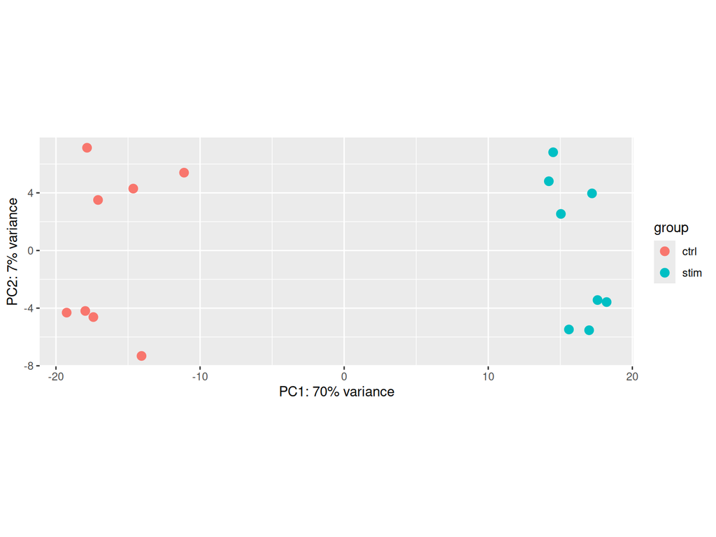

```r
# Transform counts for data visualization
rld <- rlog(dds, blind = TRUE)

# Plot PCA
DESeq2::plotPCA(rld, intgroup = "group_id")
```

We expect a clean separation on PC1 by condition, which would say that the condition of interest is the largest source of variation in the dataset.

### Hierarchical clustering

The heatmap shows the correlation of gene expression for all pairwise combinations of samples. Most genes are not differentially expressed, so samples generally correlate above 0.80. Values below 0.80 may flag an outlier or sample contamination.

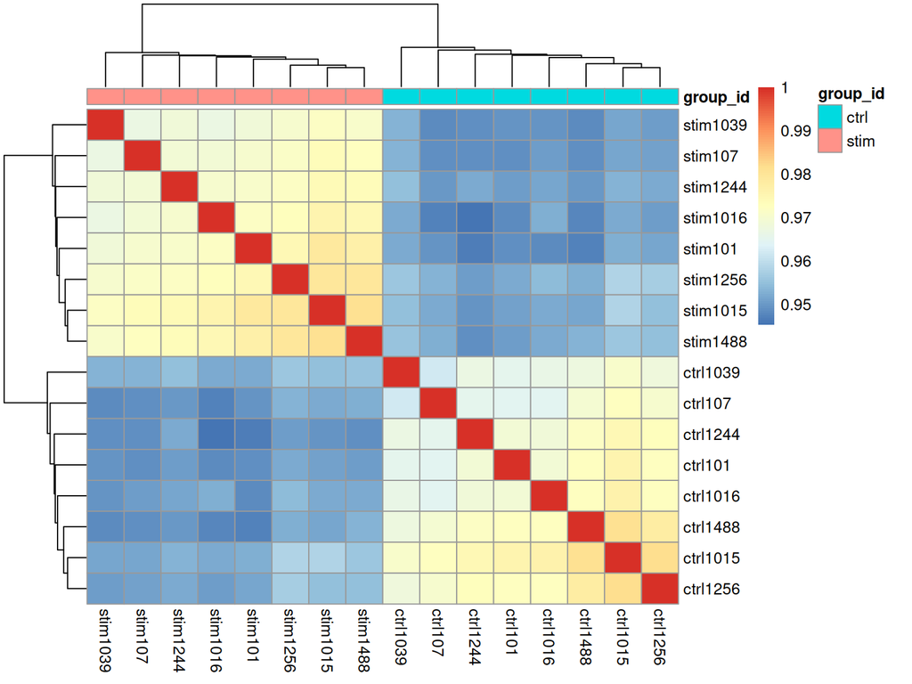

```r
# Extract the rlog matrix from the object and compute pairwise correlation values
rld_mat <- assay(rld)
rld_cor <- cor(rld_mat)

# Plot heatmap
pheatmap(rld_cor, annotation = cluster_metadata[, c("group_id"), drop = FALSE])
```

## Running DESeq2

DESeq2 models the raw counts using size factors to account for differences in library depth, estimates gene-wise dispersions and shrinks them, then fits the negative binomial model and tests with the Wald test or the likelihood ratio test. All of that happens inside the single `DESeq()` call.

```r
# Run DESeq2 differential expression analysis
dds <- DESeq(dds)
```

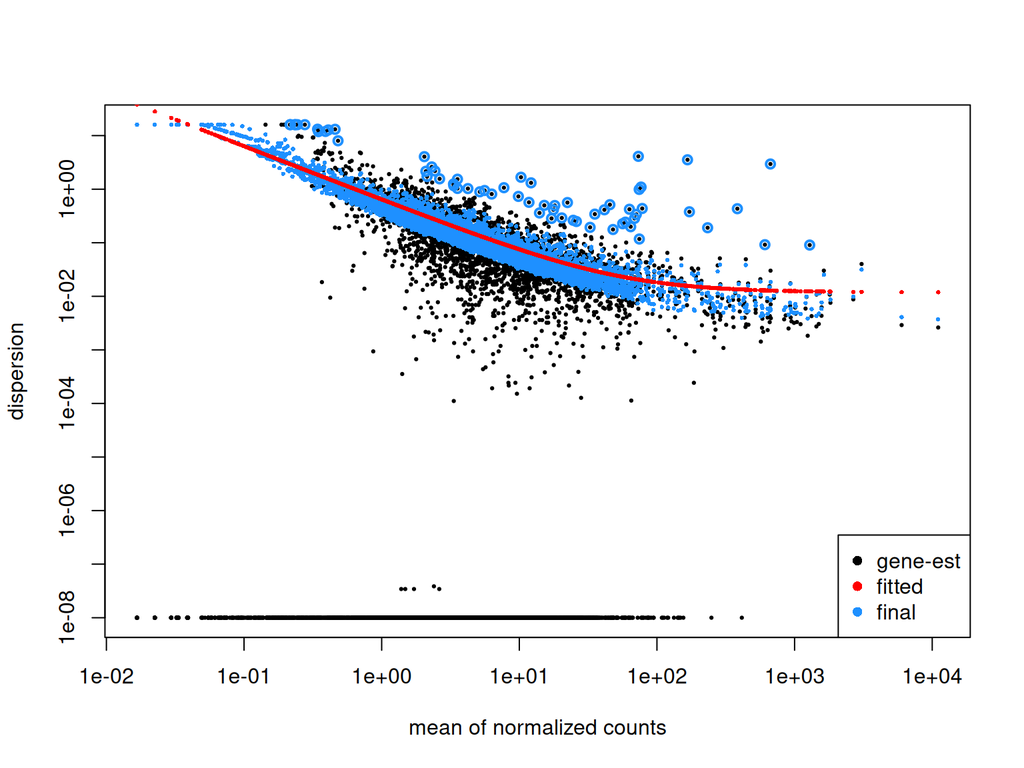

```r
# Plot dispersion estimates
plotDispEsts(dds)
```

Dispersions should decrease with increasing mean and follow the line of best fit.

## Results

We compare the stimulated group relative to the control.

```r
# Output results of Wald test for contrast for stim vs ctrl
levels(cluster_metadata$group_id)[2]
```

```
[1] "stim"
```

```r
levels(cluster_metadata$group_id)[1]
```

```
[1] "ctrl"
```

```r
contrast <- c("group_id", levels(cluster_metadata$group_id)[2], levels(cluster_metadata$group_id)[1])

# resultsNames(dds)
res <- results(dds,
               contrast = contrast,
               alpha = 0.05)

res <- lfcShrink(dds,
                 contrast = contrast,
                 res = res,
                 type = "normal")
res
```

```
log2 fold change (MAP): group_id stim vs ctrl
Wald test p-value: group id stim vs ctrl
DataFrame with 7120 rows and 6 columns
           baseMean log2FoldChange     lfcSE      stat      pvalue        padj
          <numeric>      <numeric> <numeric> <numeric>   <numeric>   <numeric>
NOC2L      11.74013       -0.26502  0.249382  -1.06285 2.87849e-01 0.614868780
HES4        4.77335        1.99663  0.467689   4.22182 2.42337e-05 0.000386247
ISG15     668.66858        5.46357  0.131779  41.31871 0.00000e+00 0.000000000
TNFRSF18    9.32975       -1.29605  0.309545  -4.17163 3.02423e-05 0.000473517
TNFRSF4     3.22265       -1.45364  0.529569  -2.72940 6.34489e-03 0.049299789
...             ...            ...       ...       ...         ...         ...
ITGB2     1.3242986     -0.5204133  0.595564 -0.871724    0.383359    0.703769
FAM207A   6.0808114     -0.2302825  0.330593 -0.696364    0.486201    0.781124
DIP2A     0.6955011     -0.8564035  0.708098 -1.213636    0.224887          NA
S100B     0.0718018     -0.0765022  0.679725 -0.124157    0.901191          NA
PRMT2    10.6036996      0.0319201  0.251888  0.126692    0.899184    0.971044
```

**Note**

Current DESeq2 defaults `lfcShrink()` to `type = "apeglm"`, which shrinks a single `coef` and rejects a `contrast =` argument. Upstream relied on the older default of `type = "normal"`, so we now pass `type = "normal"` explicitly. The alternative, `type = "apeglm"` with `coef = resultsNames(dds)[2]`, is the modern recommendation but changes the reported fold changes.

We will write out the significant genes and make a few plots.

- Table of results for all genes.
- Table of results for significant genes, adjusted p below 0.05.
- Scatterplot of normalized expression of the top 20 most significant genes.
- Heatmap of all significant genes.
- Volcano plot of results.

The tutorial writes CSV files into a `results/` folder that it assumes you created by hand when you set up the project, so we create it here.

```r
results_dir <- here::here("slides", "wed_morning", "wed_morn_tutorials", "results")
dir.create(results_dir, showWarnings = FALSE, recursive = TRUE)
results_dir
```

```
[1] "/home/steve/github/workshops2026aug/slides/wed_morning/wed_morn_tutorials/results"
```

### Table of results for all genes

```r
# Turn the results object into a tibble for use with tidyverse functions
res_tbl <- res %>%
  data.frame() %>%
  rownames_to_column(var = "gene") %>%
  as_tibble()

# Check results output
res_tbl
```

```
# A tibble: 7,120 × 7
   gene     baseMean log2FoldChange lfcSE   stat    pvalue      padj
   <chr>       <dbl>          <dbl> <dbl>  <dbl>     <dbl>     <dbl>
 1 NOC2L      11.7          -0.265  0.249 -1.06  0.288      0.615
 2 HES4        4.77          2.00   0.468  4.22  0.0000242  0.000386
 3 ISG15     669.            5.46   0.132 41.3   0          0
 4 TNFRSF18    9.33         -1.30   0.310 -4.17  0.0000302  0.000474
 5 TNFRSF4     3.22         -1.45   0.530 -2.73  0.00634    0.0493
 6 SDF4        8.63         -0.646  0.277 -2.33  0.0197     0.118
 7 UBE2J2      8.68         -0.515  0.298 -1.72  0.0849     0.316
 8 PUSL1       0.962        -1.46   0.653 -2.19  0.0287    NA
 9 CPSF3L      8.75         -0.125  0.281 -0.446 0.656      0.868
10 GLTPD1      1.65         -0.0881 0.553 -0.159 0.874      0.958
# ℹ 7,110 more rows
```

```r
# Write all results to file
write.csv(res_tbl,
          file.path(results_dir,
                    paste0(clusters[1], "_",
                           levels(cluster_metadata$group_id)[2], "_vs_",
                           levels(cluster_metadata$group_id)[1],
                           "_all_genes.csv")),
          quote = FALSE,
          row.names = FALSE)
```

**Note**

Upstream builds this filename from `levels(cluster_metadata$sample)[2]`. There is no `sample` column, only `sample_id`, so that expression is `NULL` and `paste0()` drops it, producing a file named `B cells__vs__all_genes.csv` with the condition names missing. We use `group_id` instead, which is what was meant. Upstream’s significant-genes call has a second typo on the same line, `paste0("results", ...)` with no trailing slash, which writes into the working directory rather than into `results/`. Both are fixed here.

### Table of results for significant genes

```r
# Set thresholds
padj_cutoff <- 0.05

# Subset the significant results
sig_res <- dplyr::filter(res_tbl, padj < padj_cutoff) %>%
  dplyr::arrange(padj)

# Check significant genes output
sig_res
```

```
# A tibble: 805 × 7
   gene    baseMean log2FoldChange  lfcSE  stat    pvalue      padj
   <chr>      <dbl>          <dbl>  <dbl> <dbl>     <dbl>     <dbl>
 1 ISG15       669.           5.46 0.132   41.3 0         0
 2 ISG20       740.           3.29 0.0927  35.5 1.10e-275 3.43e-272
 3 IFIT3       251.           6.64 0.205   31.3 9.91e-216 2.05e-212
 4 LY6E        163.           4.14 0.138   29.8 9.24e-195 1.44e-191
 5 IFIT1       163.           6.40 0.229   26.9 4.67e-159 5.81e-156
 6 IRF7        128.           3.67 0.148   24.7 3.24e-135 3.36e-132
 7 TNFSF10     113.           5.74 0.227   24.6 4.30e-133 3.81e-130
 8 PLSCR1      107.           4.09 0.169   24.0 1.41e-127 1.09e-124
 9 IFIT2       129.           6.01 0.242   24.0 5.87e-127 4.05e-124
10 UBE2L6      140.           2.74 0.115   23.8 1.10e-124 6.81e-122
# ℹ 795 more rows
```

```r
# Write significant results to file
write.csv(sig_res,
          file.path(results_dir,
                    paste0(clusters[1], "_",
                           levels(cluster_metadata$group_id)[2], "_vs_",
                           levels(cluster_metadata$group_id)[1],
                           "_sig_genes.csv")),
          quote = FALSE,
          row.names = FALSE)
```

### Scatterplot of normalized expression of top 20 most significant genes

This plot is a good check that we are reading the fold change direction correctly.

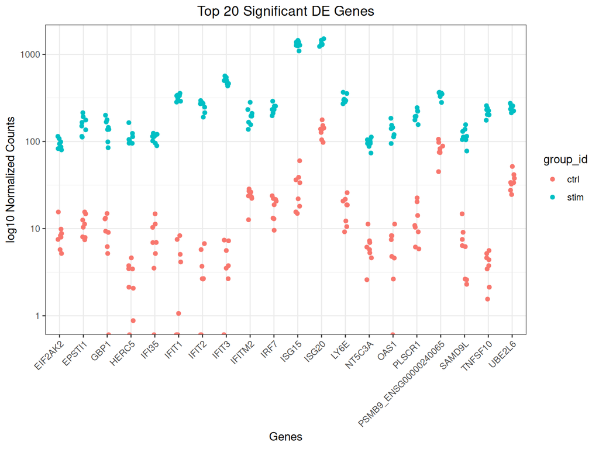

```r
## ggplot of top genes
normalized_counts <- counts(dds,
                            normalized = TRUE)

## Order results by padj values
top20_sig_genes <- sig_res %>%
  dplyr::arrange(padj) %>%
  dplyr::pull(gene) %>%
  head(n = 20)

top20_sig_norm <- data.frame(normalized_counts) %>%
  rownames_to_column(var = "gene") %>%
  dplyr::filter(gene %in% top20_sig_genes)

gathered_top20_sig <- top20_sig_norm %>%
  gather(colnames(top20_sig_norm)[2:length(colnames(top20_sig_norm))],
         key = "samplename", value = "normalized_counts")

gathered_top20_sig <- inner_join(ei[, c("sample_id", "group_id")],
                                 gathered_top20_sig,
                                 by = c("sample_id" = "samplename"))

## plot using ggplot2
ggplot(gathered_top20_sig) +
  geom_point(aes(x = gene,
                 y = normalized_counts,
                 color = group_id),
             position = position_jitter(w = 0.1, h = 0)) +
  scale_y_log10() +
  xlab("Genes") +
  ylab("log10 Normalized Counts") +
  ggtitle("Top 20 Significant DE Genes") +
  theme_bw() +
  theme(axis.text.x = element_text(angle = 45, hjust = 1)) +
  theme(plot.title = element_text(hjust = 0.5))
```

### Heatmap of all significant genes

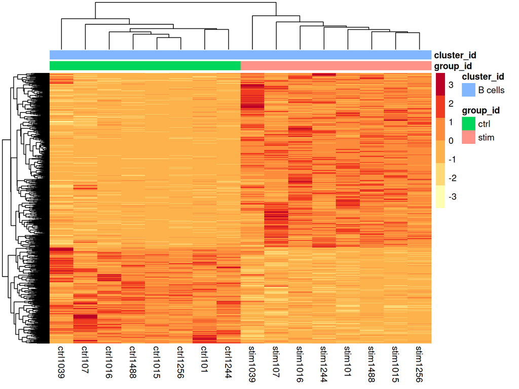

```r
# Extract normalized counts for only the significant genes
sig_norm <- data.frame(normalized_counts) %>%
  rownames_to_column(var = "gene") %>%
  dplyr::filter(gene %in% sig_res$gene)

# Set a color palette
heat_colors <- brewer.pal(6, "YlOrRd")

# Run pheatmap using the metadata data frame for the annotation
pheatmap(sig_norm[, 2:length(colnames(sig_norm))],
         color = heat_colors,
         cluster_rows = TRUE,
         show_rownames = FALSE,
         annotation = cluster_metadata[, c("group_id", "cluster_id")],
         border_color = NA,
         fontsize = 10,
         scale = "row",
         fontsize_row = 10,
         height = 20)
```

### Volcano plot of results

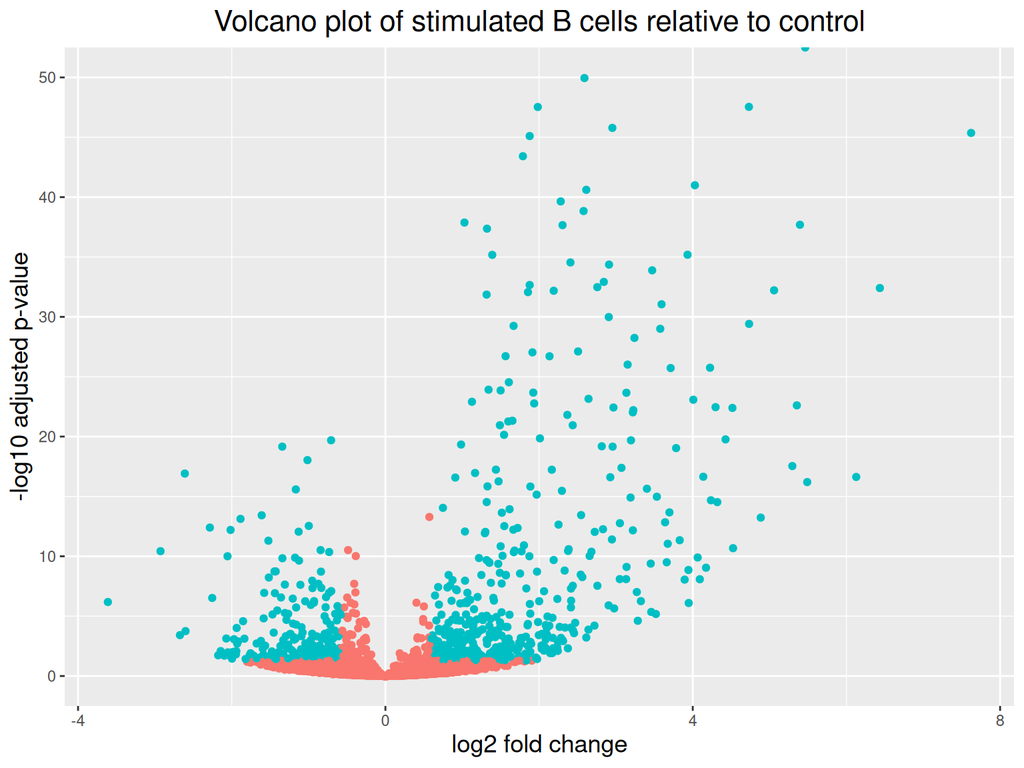

```r
## Obtain logical vector where TRUE values denote padj values < 0.05 and fold
## change > 1.5 in either direction
res_table_thres <- res_tbl %>%
  mutate(threshold = padj < 0.05 & abs(log2FoldChange) >= 0.58)

## Volcano plot
ggplot(res_table_thres) +
  geom_point(aes(x = log2FoldChange, y = -log10(padj), colour = threshold)) +
  ggtitle("Volcano plot of stimulated B cells relative to control") +
  xlab("log2 fold change") +
  ylab("-log10 adjusted p-value") +
  scale_y_continuous(limits = c(0, 50)) +
  theme(legend.position = "none",
        plot.title = element_text(size = rel(1.5), hjust = 0.5),
        axis.title = element_text(size = rel(1.25)))
```

## Useful scripts for running analyses on many different cell type clusters

### Script to run DESeq2 on all cell type clusters, Wald test

This runs DESeq2 on every cell type cluster, contrasting one level of the condition of interest against another with the Wald test. Upstream writes its output into `DESeq2/pairwise/`, and we keep that layout underneath `results_dir`.

```r
dir.create(file.path(results_dir, "DESeq2"), showWarnings = FALSE)
dir.create(file.path(results_dir, "DESeq2", "pairwise"), showWarnings = FALSE)

# Function to run DESeq2 and get results for all clusters
## x is index of cluster in clusters vector on which to run function
## A is the sample group to compare
## B is the sample group to compare against (base level)

get_dds_resultsAvsB <- function(x, A, B) {
  cluster_metadata <- metadata[which(metadata$cluster_id == clusters[x]), ]
  rownames(cluster_metadata) <- cluster_metadata$sample_id
  cluster_metadata$group_id <- factor(cluster_metadata$group_id)
  counts <- pb[[clusters[x]]]
  cluster_counts <- data.frame(counts[, which(colnames(counts) %in% rownames(cluster_metadata))])

  # all(rownames(cluster_metadata) == colnames(cluster_counts))

  dds <- DESeqDataSetFromMatrix(cluster_counts,
                                colData = cluster_metadata,
                                design = ~ group_id)

  # Transform counts for data visualization
  rld <- rlog(dds, blind = TRUE)

  # Plot PCA
  DESeq2::plotPCA(rld, intgroup = "group_id")
  ggsave(file.path(results_dir, paste0(clusters[x], "_specific_PCAplot.png")))

  # Extract the rlog matrix from the object and compute pairwise correlation values
  rld_mat <- assay(rld)
  rld_cor <- cor(rld_mat)

  # Plot heatmap
  png(file.path(results_dir, paste0(clusters[x], "_specific_heatmap.png")))
  pheatmap(rld_cor, annotation = cluster_metadata[, c("group_id"), drop = FALSE])
  dev.off()

  # Run DESeq2 differential expression analysis
  dds <- DESeq(dds)

  # Plot dispersion estimates
  png(file.path(results_dir, paste0(clusters[x], "_dispersion_plot.png")))
  plotDispEsts(dds)
  dev.off()

  # Output results of Wald test for contrast for A vs B
  contrast <- c("group_id", levels(cluster_metadata$group_id)[A], levels(cluster_metadata$group_id)[B])

  # resultsNames(dds)
  res <- results(dds,
                 contrast = contrast,
                 alpha = 0.05)

  res <- lfcShrink(dds,
                   contrast = contrast,
                   res = res,
                   type = "normal")
  # Set thresholds
  padj_cutoff <- 0.05

  # Turn the results object into a tibble for use with tidyverse functions
  res_tbl <- res %>%
    data.frame() %>%
    rownames_to_column(var = "gene") %>%
    as_tibble()

  write.csv(res_tbl,
            file.path(results_dir, "DESeq2", "pairwise",
                      paste0(clusters[x], "_",
                             levels(cluster_metadata$group_id)[A], "_vs_",
                             levels(cluster_metadata$group_id)[B],
                             "_all_genes.csv")),
            quote = FALSE,
            row.names = FALSE)

  # Subset the significant results
  sig_res <- dplyr::filter(res_tbl, padj < padj_cutoff) %>%
    dplyr::arrange(padj)

  write.csv(sig_res,
            file.path(results_dir, "DESeq2", "pairwise",
                      paste0(clusters[x], "_",
                             levels(cluster_metadata$group_id)[A], "_vs_",
                             levels(cluster_metadata$group_id)[B],
                             "_sig_genes.csv")),
            quote = FALSE,
            row.names = FALSE)

  ## ggplot of top genes
  normalized_counts <- counts(dds,
                              normalized = TRUE)

  ## Order results by padj values
  top20_sig_genes <- sig_res %>%
    dplyr::arrange(padj) %>%
    dplyr::pull(gene) %>%
    head(n = 20)

  top20_sig_norm <- data.frame(normalized_counts) %>%
    rownames_to_column(var = "gene") %>%
    dplyr::filter(gene %in% top20_sig_genes)

  gathered_top20_sig <- top20_sig_norm %>%
    gather(colnames(top20_sig_norm)[2:length(colnames(top20_sig_norm))],
           key = "samplename", value = "normalized_counts")

  gathered_top20_sig <- inner_join(ei[, c("sample_id", "group_id")],
                                   gathered_top20_sig,
                                   by = c("sample_id" = "samplename"))

  ## plot using ggplot2
  ggplot(gathered_top20_sig) +
    geom_point(aes(x = gene,
                   y = normalized_counts,
                   color = group_id),
               position = position_jitter(w = 0.1, h = 0)) +
    scale_y_log10() +
    xlab("Genes") +
    ylab("log10 Normalized Counts") +
    ggtitle("Top 20 Significant DE Genes") +
    theme_bw() +
    theme(axis.text.x = element_text(angle = 45, hjust = 1)) +
    theme(plot.title = element_text(hjust = 0.5))
  ggsave(file.path(results_dir, "DESeq2", "pairwise",
                   paste0(clusters[x], "_",
                          levels(cluster_metadata$group_id)[A], "_vs_",
                          levels(cluster_metadata$group_id)[B],
                          "_top20_DE_genes.png")))
}
```

Upstream calls this with a bare `map()`, which aborts the whole sweep at the first cluster that fails. Small clusters such as Megakaryocytes can easily fail, so we wrap each call so that one failure does not hide the other seven.

```r
# Run the script on all clusters comparing stim condition relative to control
# condition
wald_outcomes <- map(1:length(clusters),
                     function(i) {
                       tryCatch(get_dds_resultsAvsB(i, A = 2, B = 1),
                                error = function(e) {
                                  message("Cluster ", clusters[i], " failed: ",
                                          conditionMessage(e))
                                  conditionMessage(e)
                                })
                     })
names(wald_outcomes) <- clusters
```

### Script to run DESeq2 on all cell type clusters, likelihood ratio test

```r
# Likelihood ratio test
dir.create(file.path(results_dir, "DESeq2", "lrt"), showWarnings = FALSE)

# Create DESeq2Dataset object
clusters <- levels(factor(metadata$cluster_id))

metadata <- gg_df %>%
  dplyr::select(cluster_id, sample_id, group_id)

metadata$group <- paste0(metadata$cluster_id, "_", metadata$group_id) %>%
  factor()
```

```r
# DESeq2
library(DEGreport)
get_dds_LRTresults <- function(x) {

  cluster_metadata <- metadata[which(metadata$cluster_id == clusters[x]), ]
  rownames(cluster_metadata) <- cluster_metadata$sample_id
  cluster_metadata$group_id <- factor(cluster_metadata$group_id)
  counts <- pb[[clusters[x]]]
  cluster_counts <- data.frame(counts[, which(colnames(counts) %in% rownames(cluster_metadata))])

  # all(rownames(cluster_metadata) == colnames(cluster_counts))

  dds <- DESeqDataSetFromMatrix(cluster_counts,
                                colData = cluster_metadata,
                                design = ~ group_id)

  dds_lrt <- DESeq(dds, test = "LRT", reduced = ~ 1)

  # Extract results
  res_LRT <- results(dds_lrt)

  # Create a tibble for LRT results
  res_LRT_tb <- res_LRT %>%
    data.frame() %>%
    rownames_to_column(var = "gene") %>%
    as_tibble()

  # Save all results
  write.csv(res_LRT_tb,
            file.path(results_dir, "DESeq2", "lrt",
                      paste0(clusters[x], "_LRT_all_genes.csv")),
            quote = FALSE,
            row.names = FALSE)

  # Subset to return genes with padj < 0.05
  sigLRT_genes <- res_LRT_tb %>%
    dplyr::filter(padj < 0.05)

  # Save sig results
  write.csv(sigLRT_genes,
            file.path(results_dir, "DESeq2", "lrt",
                      paste0(clusters[x], "_LRT_sig_genes.csv")),
            quote = FALSE,
            row.names = FALSE)

  # Transform counts for data visualization
  rld <- rlog(dds_lrt, blind = TRUE)

  # Extract the rlog matrix from the object and compute pairwise correlation values
  rld_mat <- assay(rld)
  rld_cor <- cor(rld_mat)

  # Obtain rlog values for those significant genes
  cluster_rlog <- rld_mat[sigLRT_genes$gene, ]

  cluster_meta_sig <- cluster_metadata[which(rownames(cluster_metadata) %in% colnames(cluster_rlog)), ]

  # # Remove samples without replicates
  # cluster_rlog <- cluster_rlog[, -1]
  # cluster_metadata <- cluster_metadata[which(rownames(cluster_metadata) %in% colnames(cluster_rlog)), ]

  # Use the `degPatterns` function from the 'DEGreport' package to show gene
  # clusters across sample groups
  cluster_groups <- degPatterns(cluster_rlog, metadata = cluster_meta_sig,
                                time = "group_id", col = NULL)
  ggsave(file.path(results_dir, "DESeq2", "lrt",
                   paste0(clusters[x], "_LRT_DEgene_groups.png")))

  # Let's see what is stored in the `df` component
  write.csv(cluster_groups$df,
            file.path(results_dir, "DESeq2", "lrt",
                      paste0(clusters[x], "_LRT_DEgene_groups.csv")),
            quote = FALSE,
            row.names = FALSE)

  saveRDS(cluster_groups,
          file.path(results_dir, "DESeq2", "lrt",
                    paste0(clusters[x], "_LRT_DEgene_groups.rds")))
  save(dds_lrt, cluster_groups, res_LRT, sigLRT_genes,
       file = file.path(results_dir, "DESeq2", "lrt",
                        paste0(clusters[x], "_all_LRTresults.Rdata")))
}
```

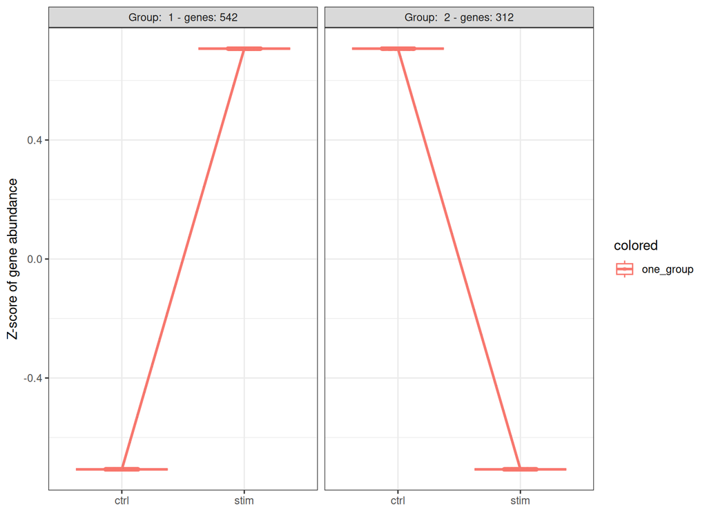

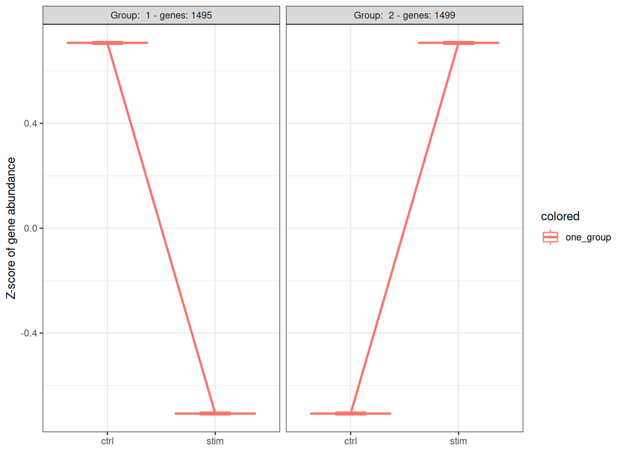

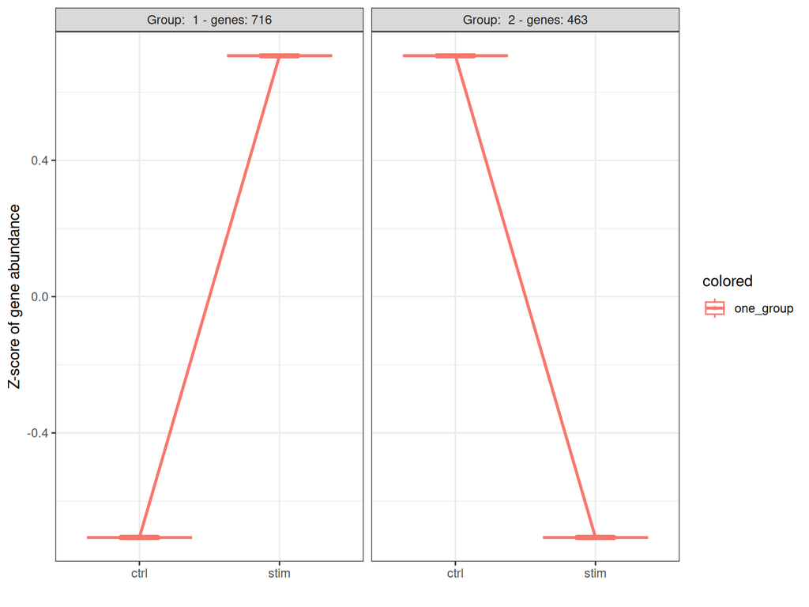

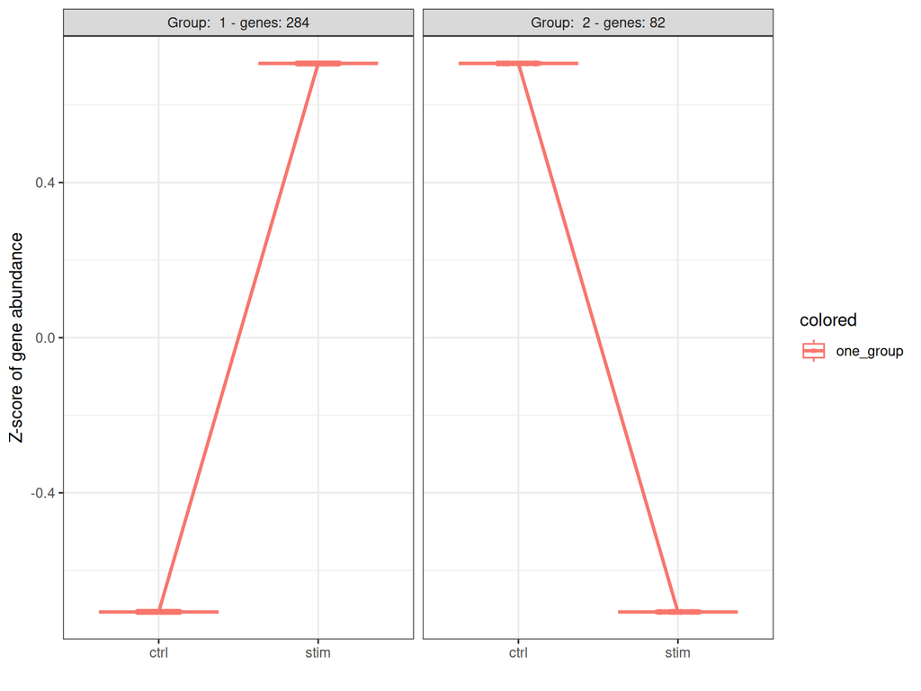

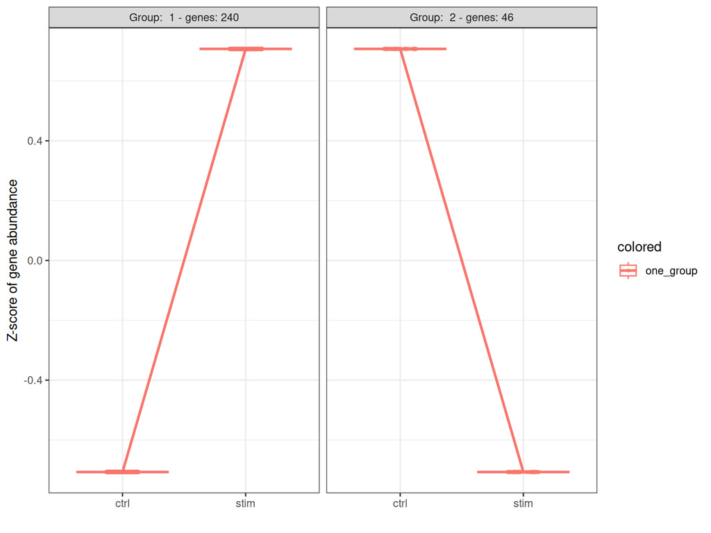

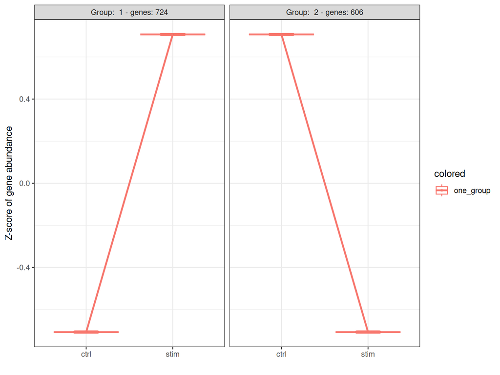

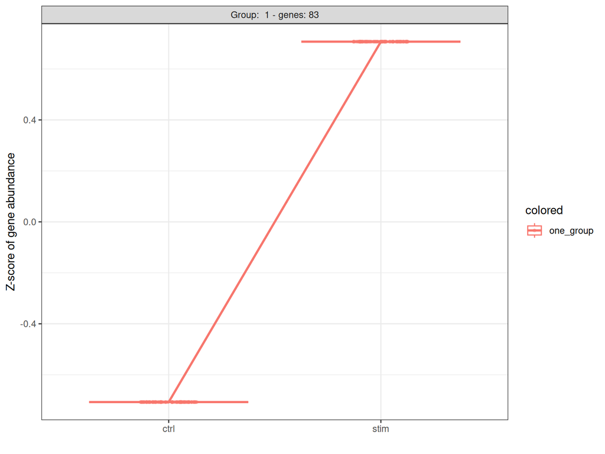

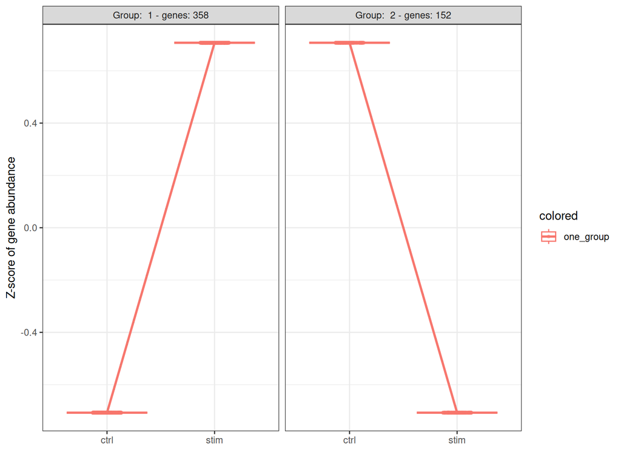

```r
lrt_outcomes <- map(1:length(clusters),
                    function(i) {
                      tryCatch(get_dds_LRTresults(i),
                               error = function(e) {
                                 message("Cluster ", clusters[i], " failed: ",
                                         conditionMessage(e))
                                 conditionMessage(e)
                               })
                    })
```

```r
names(lrt_outcomes) <- clusters
```

**Note**

The LRT here compares `~ group_id` against `~ 1`, which with a two-level factor is close to the Wald test above rather than a genuinely multi-group design. The upstream lesson presents it as a template to adapt when there are three or more groups.